# final project

```python
from sagemaker.inputs import TrainingInput

train_input = TrainingInput(train_path+"/train.csv",content_type='csv') # reformats training data for XGBoost
test_input = TrainingInput(test_path+"/validation.csv",content_type='csv') # reformats testing data for XGBoost
```

```python
from sagemaker import image_uris
from sagemaker.debugger import Rule, rule_configs

container = sagemaker.image_uris.retrieve("xgboost", region, "1.7-1") # sets name of container holding model
rules=[Rule.sagemaker(rule_configs.create_xgboost_report())] # creates a summary / report of training model performance
```

```python
# creates dictionary of parameter ranges to be tried in hyperparameter tuning job

tuning_job_config = {
    "ParameterRanges": {
      "CategoricalParameterRanges": [],
      "ContinuousParameterRanges": [
        {
          "MaxValue": "1",
          "MinValue": "0",
          "Name": "eta"
        },
        {
          "MaxValue": "2",
          "MinValue": "0",
          "Name": "alpha"
        },
        {
          "MaxValue": "10",
          "MinValue": "0",
          "Name": "gamma"
        },
        {
          "MaxValue": "10",
          "MinValue": "1",
          "Name": "min_child_weight"
        },
        {
          "MaxValue": "5",
          "MinValue": "0",
          "Name": "lambda"
        },
        {
          "MaxValue": "1",
          "MinValue": "0.5",
          "Name": "subsample"
        }
      ],
      "IntegerParameterRanges": [
        {
          "MaxValue": "20",
          "MinValue": "1",
          "Name": "max_depth"
        }
      ]
    },
    "ResourceLimits": {
      "MaxNumberOfTrainingJobs": 20,
      "MaxParallelTrainingJobs": 3
    },
    "Strategy": "Bayesian",
    "HyperParameterTuningJobObjective": {
      "MetricName": "validation:rmse",
      "Type": "Minimize"
    },
    "RandomSeed" : 123
  }
```

```python
s3_input_train = 's3://{}/{}/train'.format(bucket, prefix) # sets import path for tuning job training data
s3_input_validation ='s3://{}/{}/validation/'.format(bucket, prefix) # sets import path for tuning job testing data


# defines training job model, parameters
training_job_definition = {
    "AlgorithmSpecification": {
      "TrainingImage": container,
      "TrainingInputMode": "File"
    },
    "InputDataConfig": [
      {
        "ChannelName": "train",
        "CompressionType": "None",
        "ContentType": "csv",
        "DataSource": {
          "S3DataSource": {
            "S3DataDistributionType": "FullyReplicated",
            "S3DataType": "S3Prefix",
            "S3Uri": s3_input_train
          }
        }
      },
      {
        "ChannelName": "validation",
        "CompressionType": "None",
        "ContentType": "csv",
        "DataSource": {
          "S3DataSource": {
            "S3DataDistributionType": "FullyReplicated",
            "S3DataType": "S3Prefix",
            "S3Uri": s3_input_validation
          }
        }
      }
    ],
    "OutputDataConfig": {
      "S3OutputPath": "s3://{}/{}/output".format(bucket,prefix)
    },
    "ResourceConfig": {
      "InstanceCount": 2,
      "InstanceType": "ml.c4.2xlarge",
      "VolumeSizeInGB": 10
    },
    "RoleArn": role,
    "StaticHyperParameters": {
      "eval_metric": "rmse",
      "num_round": "100",
      "objective": "reg:squarederror",
      "rate_drop": "0.3",
      "tweedie_variance_power": "1.4"
    },
    "StoppingCondition": {
      "MaxRuntimeInSeconds": 43200
    }
}
```

```python
# initiates hyperparameter tuning job

tuning_job_name = "forecasting-sales-xgboost-01"
smclient.create_hyper_parameter_tuning_job(HyperParameterTuningJobName = tuning_job_name,
                                           HyperParameterTuningJobConfig = tuning_job_config,
                                           TrainingJobDefinition = training_job_definition)
```

```
{'HyperParameterTuningJobArn': 'arn:aws:sagemaker:us-east-1:810066614360:hyper-parameter-tuning-job/forecasting-sales-xgboost-01',
 'ResponseMetadata': {'RequestId': 'b2d2c59a-576a-4257-a54b-cdbcb7ab77c0',
  'HTTPStatusCode': 200,
  'HTTPHeaders': {'x-amzn-requestid': 'b2d2c59a-576a-4257-a54b-cdbcb7ab77c0',
   'content-type': 'application/x-amz-json-1.1',
   'content-length': '129',
   'date': 'Tue, 29 Aug 2023 20:29:39 GMT'},
  'RetryAttempts': 0}}
```

```python
# defines model we will be training
xgb = sagemaker.estimator.Estimator(
    image_uri = container,
    role = role,
    instance_count=1,
    instance_type="ml.m4.xlarge",
    output_path=output_path,
    sagemaker_session=sagemaker_session,
    rules=rules
)

# sets hyperparameters based on best results from hyperparameter tuning job
xgb.set_hyperparameters(

    max_depth=20,
    alpha = 0.4468623897150033,
    eta=0.14237189295655897,
    reg_lambda = 4.440105631644935,
    gamma=5.653530288377314,
    min_child_weight=10,
    subsample=0.8060900326169855,
    verbosity=0,
    objective="reg:squarederror",
    num_round=100,
    rate_drop =0.3,
    tweedie_variance_power = 1.4,
    eval_metric = "rmse",
    early_stopping_rounds = 10
)
```

```python
xgb.fit({"train": train_input, "validation": test_input}) # fit model to our data
```

```
INFO:sagemaker:Creating training-job with name: sagemaker-xgboost-2023-08-29-20-29-40-661
```

[output not shown]

[output cut: 80 more lines]

```
[90]#011train-rmse:0.60515#011validation-rmse:0.75741
[91]#011train-rmse:0.60323#011validation-rmse:0.75759
[92]#011train-rmse:0.59951#011validation-rmse:0.75680
[93]#011train-rmse:0.59837#011validation-rmse:0.75686
[94]#011train-rmse:0.59737#011validation-rmse:0.75701
[95]#011train-rmse:0.59543#011validation-rmse:0.75655
[96]#011train-rmse:0.59396#011validation-rmse:0.75659
[97]#011train-rmse:0.59307#011validation-rmse:0.75650
[98]#011train-rmse:0.59094#011validation-rmse:0.75612

2023-08-29 21:24:20 Uploading - Uploading generated training model
2023-08-29 21:24:20 Completed - Training job completed
[99]#011train-rmse:0.58853#011validation-rmse:0.75570
Training seconds: 3170
Billable seconds: 3170
```

Model testing and validation

```python
from sagemaker.serializers import CSVSerializer

# Deploys endpoint to host model that we will call to create predictions on our data.
predictor = xgb.deploy(
    initial_instance_count=1, instance_type="ml.m5.xlarge", serializer=CSVSerializer())
```

```
INFO:sagemaker:Creating model with name: sagemaker-xgboost-2023-08-29-21-24-31-414
INFO:sagemaker:Creating endpoint-config with name sagemaker-xgboost-2023-08-29-21-24-31-414
INFO:sagemaker:Creating endpoint with name sagemaker-xgboost-2023-08-29-21-24-31-414
```

```
----!
```

```python
# creates function that reformats our input data to be sent to model for predictions
def predictionator_2(data, rows=1000):
    split_array = np.array_split(data, int(data.shape[0] / float(rows) + 1)) # splits data into chunks to be more easily processed
    predictions = "" # creates empty string to store predicted values
    for array in split_array:
        predictions = "".join([predictions, predictor.predict(array).decode("utf-8")]) # appends predicted values to 'predictions'

    return predictions.split("\n")[:-1] # returns list of predicted values
```

```python
x_test_preds = X_test.drop(['scaled_residuals'], axis=1) # removes y value from our test data
```

```python
x_test_preds.head()
```

|  | onpromotion | national_holi | local_holi | regional_holi | new_year | payday | earthquake | dcoilwtico | percip | max_temp | ... | family_MAGAZINES | family_MEATS | family_PERSONAL CARE | family_PET SUPPLIES | family_PLAYERS AND ELECTRONICS | family_POULTRY | family_PREPARED FOODS | family_PRODUCE | family_SCHOOL AND OFFICE SUPPLIES | family_SEAFOOD |
| --- | --- | --- | --- | --- | --- | --- | --- | --- | --- | --- | --- | --- | --- | --- | --- | --- | --- | --- | --- | --- | --- |
| 1418985 | 0.000000 | 0 | 0 | 0 | 0 | 0 | 0.0 | 0.437715 | 0.701623 | 0.500000 | ... | 0.0 | 0.0 | 0.0 | 0.0 | 0.0 | 0.0 | 0.0 | 0.0 | 0.0 | 0.0 |
| 464690 | 0.000000 | 0 | 0 | 0 | 0 | 0 | 0.0 | 0.978395 | 0.078207 | 0.532468 | ... | 0.0 | 0.0 | 0.0 | 0.0 | 0.0 | 0.0 | 0.0 | 0.0 | 0.0 | 0.0 |
| 1547873 | 0.005398 | 0 | 0 | 0 | 0 | 0 | 0.0 | 0.544025 | 0.777835 | 0.759740 | ... | 0.0 | 0.0 | 0.0 | 0.0 | 0.0 | 0.0 | 0.0 | 0.0 | 0.0 | 0.0 |
| 599239 | 0.000000 | 0 | 0 | 0 | 0 | 0 | 0.0 | 0.866299 | 0.103693 | 0.594156 | ... | 0.0 | 0.0 | 1.0 | 0.0 | 0.0 | 0.0 | 0.0 | 0.0 | 0.0 | 0.0 |
| 2463647 | 0.000000 | 0 | 0 | 0 | 0 | 0 | 0.0 | 0.451727 | 0.057802 | 0.707792 | ... | 0.0 | 0.0 | 0.0 | 0.0 | 0.0 | 0.0 | 0.0 | 0.0 | 0.0 | 1.0 |

5 rows × 128 columns

```python
predictions = predictionator_2(x_test_preds.to_numpy()[:,:]) # predicts scaled residual values from our test data
```

```python
len(predictions)
```

```
584956
```

```python
x_test_preds = X_test[:] # creates copy of unprocessed test data
```

```python
x_test_preds['predictions'] = predictions # adds our model predictions as a column to test dataframe
```

```python
x_test_preds['predictions'] = x_test_preds['predictions'].astype('float32') # coverts predictions from string to float
```

```python
x_test_preds = pd.DataFrame(x_test_preds['predictions']) # reduces dataframe to just predictions
```

```python
resid_plot = residuals[['sales','pred_sales','resid','id', 'date']] # creates dataframe containing relevant plotting info
```

```python
x_test_plot = x_test_preds.merge(resid_plot, how='left', left_index=True, right_on ='id') # adds predictions to dataframe
```

```python
x_test_plot.head()
```

|  | predictions | sales | pred_sales | resid | id | date |
| --- | --- | --- | --- | --- | --- | --- |
| 1419216 | -0.011197 | 0.0 | 9.923547 | -9.923547 | 1418985 | 2015-03-10 |
| 464855 | -0.004010 | 2.0 | 1.918664 | 0.081336 | 464690 | 2013-09-18 |
| 1546883 | -0.084081 | 611.0 | 727.339470 | -116.339470 | 1547873 | 2015-05-21 |
| 599470 | -0.004010 | 0.0 | -0.437537 | 0.437537 | 599239 | 2013-12-03 |
| 2463845 | -0.008378 | 10.0 | 3.985513 | 6.014487 | 2463647 | 2016-10-17 |

```python
# convert our predictions from standardized to predicted residuals
x_test_plot['unscaled_residuals_test'] = np.round(stand_scaler.inverse_transform(x_test_plot['predictions'].values.reshape(-1,1)), 3)
# create scaled residual column for plotting
x_test_plot['scaled_residuals'] = stand_scaler.transform(x_test_plot['resid'].values.reshape(-1,1))
```

```python
x_test_plot['resid'] = x_test_plot['resid'].astype('float64') # converts actual residual values from string to float
x_test_plot['unscaled_residuals_test'] = x_test_plot['unscaled_residuals_test'].astype('float64') # converts unscaled residual values to float
```

```python
preds_plot_2 = x_test_plot.groupby(['date']).sum() # groups dataframe by date, calculates sum
```

```python
preds_plot_2 = preds_plot_2.sort_values(by=['date']) # sorts dataframe by date
```

```
<function matplotlib.pyplot.show(close=None, block=None)>
```

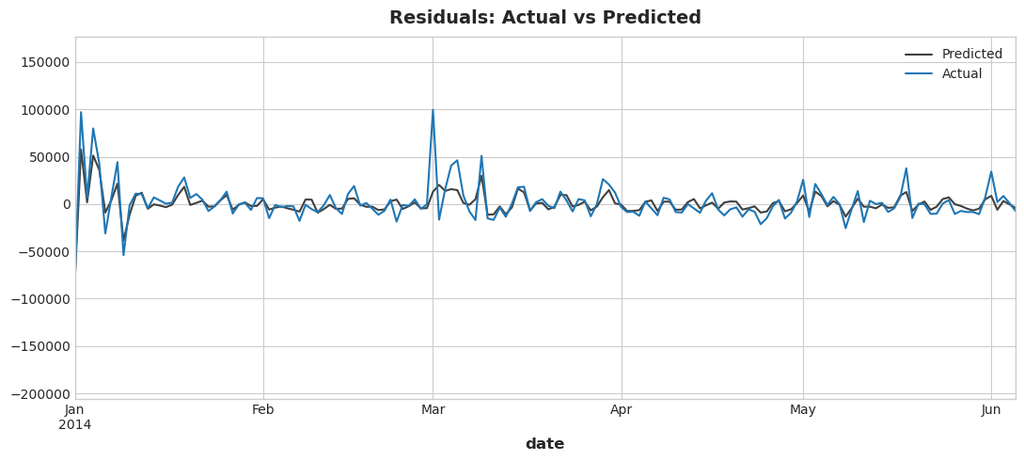

```python
ax = preds_plot_2['unscaled_residuals_test'].plot(color='0.25', title="Residuals: Actual vs Predicted", label ='Predicted') # plots predicted residual values
ax = preds_plot_2['resid'].plot(ax=ax, label="Actual") # plots actual residual values
_ = ax.legend() # creates legend for plot
plt.xlim(['2014-01-01', '2014-06-05']) # sets date range to show on plot
plt.show
```

```python
# computes RMSE for unscaled predicted residuals vs actual residuals
np.sqrt(mean_squared_error(preds_plot_2['unscaled_residuals_test'], preds_plot_2['resid']))
```

```
11453.586741933177
```

```python
# computes RMSE for predictions vs standardized residuals
np.sqrt(mean_squared_error(x_test_plot['predictions'], x_test_plot['scaled_residuals']))
```

```
0.7556966226643923
```

```
<function matplotlib.pyplot.show(close=None, block=None)>
```

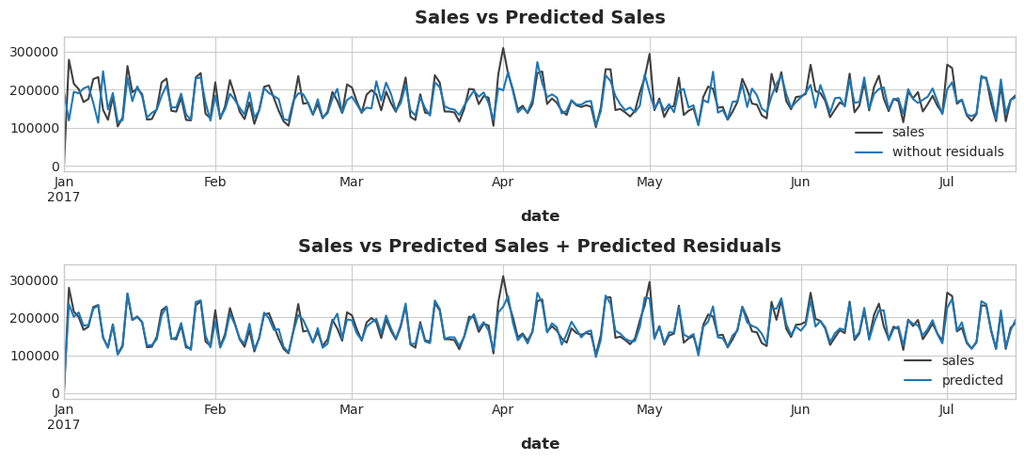

```python
fig, (ax1, ax2) = plt.subplots(2)
preds_plot_2['sales'].plot(color='0.25', title="Sales vs Predicted Sales", ax=ax1) # plots provided sales values
preds_plot_2['sales'].plot(color='0.25', title="Sales vs Predicted Sales + Predicted Residuals", ax=ax2) # plots provided sales values
preds_plot_2['pred_sales'].plot(ax=ax1, label="without residuals") # plots predicted sales values
(preds_plot_2['unscaled_residuals_test']+ preds_plot_2['pred_sales']).plot(ax=ax2, label="predicted") # plots combined predicted values (sales and residuals)
_ = ax1.legend() # creates legend for plot
_ = ax2.legend() # creates legend for plot
plt.setp(ax1, xlim=(['2017-01-01', '2017-07-15']))# sets date range to show on plot
plt.setp(ax2, xlim=(['2017-01-01', '2017-07-15']))# sets date range to show on plot
plt.show
```

```python
# computes RMSE for sales vs predicuted sales
predicted_RMSE = np.sqrt(mean_squared_error(preds_plot_2['sales'], preds_plot_2['pred_sales']))
# computes RMSE for sales vs combined predictions
predicted_res_RMSE = np.sqrt(mean_squared_error((preds_plot_2['pred_sales']+preds_plot_2['unscaled_residuals_test']), preds_plot_2['sales']))
```

```python
print(predicted_RMSE)
print(predicted_res_RMSE)
```

```
20280.416487153474
11453.586741933179
```

Validation

```python
validation.head() # view validation dataset
```

|  | id | date | store_nbr | family | onpromotion | national_holi | local_holi | regional_holi | new_year | payday | earthquake | dow | month | dcoilwtico | percip | max_temp | resid |
| --- | --- | --- | --- | --- | --- | --- | --- | --- | --- | --- | --- | --- | --- | --- | --- | --- | --- |
| 2945646 | 2945646 | 2017-07-16 | 1 | AUTOMOTIVE | 0 | 0 | 0 | 0 | 0 | 0 | 0.0 | 6 | 7 | 0.0 | 94.17 | 26.54 | -2.395900 |
| 2945647 | 2945647 | 2017-07-16 | 1 | BABY CARE | 0 | 0 | 0 | 0 | 0 | 0 | 0.0 | 6 | 7 | 0.0 | 94.17 | 26.54 | 0.000000 |
| 2945648 | 2945648 | 2017-07-16 | 1 | BEAUTY | 0 | 0 | 0 | 0 | 0 | 0 | 0.0 | 6 | 7 | 0.0 | 94.17 | 26.54 | -1.703477 |
| 2945649 | 2945649 | 2017-07-16 | 1 | BEVERAGES | 34 | 0 | 0 | 0 | 0 | 0 | 0.0 | 6 | 7 | 0.0 | 94.17 | 26.54 | -560.648232 |
| 2945650 | 2945650 | 2017-07-16 | 1 | BOOKS | 0 | 0 | 0 | 0 | 0 | 0 | 0.0 | 6 | 7 | 0.0 | 94.17 | 26.54 | -0.315967 |

Append validation to original dataset to get accurate lag values

```python
forcasting = full[:] # retrives full dataset up to 2017-7-15
```

```python
forcasting['scaled_residuals'] = stand_scaler.transform(forcasting['resid'].values.reshape(-1,1)) # adds scaled residuals to dataframe (Y value)
```

```python
forcasting = pd.concat([forcasting,validation]) # combines validation set with original dataset
```

```python
all_data = forcasting[:] # saves full dataset for later use
```

Because we are using lag values, we will be predicting one day at a time, then appending those predictions on to our dataframe (under scaled_residuals) to be used for the next date's lag variables

```python
forcasting.head()
```

|  | id | date | store_nbr | family | onpromotion | national_holi | local_holi | regional_holi | new_year | payday | earthquake | dow | month | dcoilwtico | percip | max_temp | resid | scaled_residuals |
| --- | --- | --- | --- | --- | --- | --- | --- | --- | --- | --- | --- | --- | --- | --- | --- | --- | --- | --- |
| 0 | 0 | 2013-01-01 | 1 | AUTOMOTIVE | 0 | 1 | 0 | 0 | 1 | 0 | 0.0 | 1 | 1 | 0.0 | 183.27 | 27.73 | -1.542533 | -0.004767 |
| 1 | 1 | 2013-01-01 | 1 | BABY CARE | 0 | 1 | 0 | 0 | 1 | 0 | 0.0 | 1 | 1 | 0.0 | 183.27 | 27.73 | 0.000000 | 0.000429 |
| 2 | 2 | 2013-01-01 | 1 | BEAUTY | 0 | 1 | 0 | 0 | 1 | 0 | 0.0 | 1 | 1 | 0.0 | 183.27 | 27.73 | -1.648604 | -0.005124 |
| 3 | 3 | 2013-01-01 | 1 | BEVERAGES | 0 | 1 | 0 | 0 | 1 | 0 | 0.0 | 1 | 1 | 0.0 | 183.27 | 27.73 | -285.912715 | -0.962626 |
| 4 | 4 | 2013-01-01 | 1 | BOOKS | 0 | 1 | 0 | 0 | 1 | 0 | 0.0 | 1 | 1 | 0.0 | 183.27 | 27.73 | -0.055483 | 0.000242 |

```python
# creates list of dates we will be prediciting values for
dates = ['2017-07-16',
 '2017-07-17', '2017-07-18', '2017-07-19', '2017-07-20', '2017-07-21',
 '2017-07-22', '2017-07-23', '2017-07-24', '2017-07-25', '2017-07-26',
 '2017-07-27', '2017-07-28', '2017-07-29', '2017-07-30']
```

```python
tail_1 = forcasting[forcasting['date'] <= '2017-07-15']
tail_2 = tail_1[tail_1['date'] > '2016-05-01']

for idx, item in enumerate(dates):
    df_lags = pd.DataFrame(columns = ['y_lag_1','y_lag_2','y_lag_3','y_lag_4','y_lag_5','y_lag_6','y_lag_7','y_lag_8','y_lag_9','y_lag_10','y_lag_11','y_lag_12'])# creates empty dataframe to store lag data

    temp = forcasting[forcasting['date'] == item] # creates dataframe of predicting info for selected date

    data = pd.concat([tail_2, temp]) # appends temp to dataframe


    for n in list(range(1,55)): # iterates through store numbers
        for idx2, item2 in enumerate(cats): # iterates through family values
            frame = data.query('store_nbr == '+str(n)+' and family == '+'"'+item2+'"') # creates dataframe of data from selected store / family

            frame = frame.set_index('id') # sets id column as the dataframe index

            arry = frame['scaled_residuals'] # creates Series of scaled residual values

            lags = make_lags(arry, lags=12) # creates 12 lag variables from scaled residuals

            df_lags = pd.concat([df_lags,lags]) # appends store / family lag data to lag dataframe


    data[['onpromotion','dow','month','dcoilwtico','percip','max_temp']] = max_scaler.transform(data[['onpromotion','dow','month','dcoilwtico','percip','max_temp']]) # scales appropriate columns using min/max scaler

    data = pd.get_dummies(data, columns = ['store_nbr','dow','month','family',], dtype='float32') # creates dummy variables (0 or 1) for appropriate columns

    plus = data.merge(df_lags, how='left', left_index=True,  right_index=True) # adds lag data to features dataframe

    plus_16 = plus[plus['date'] == item] # singles out date we are predicting

    plus_16 = plus_16.drop(['scaled_residuals','resid'], axis=1) # drops un-necessary columns

    col_list = X_test.drop('scaled_residuals', axis=1).columns # list of columns in correct order for prediction

    plus_16 = plus_16[col_list] # rearranges our dataframe into correct order for prediction

    predictions = predictionator_2(plus_16.to_numpy()[:,:]) # predicts scaled residuals

    new_tail = forcasting[forcasting['date'] == item] # collects data to be appended to original dataset

    new_tail['scaled_residuals'] = predictions # adds newly predicted values to data

    tail_2 = pd.concat([tail_2, new_tail]) # appends data to end of original dataset for next date's predicting
```

```python
tail_2.tail()
```

|  | id | date | store_nbr | family | onpromotion | national_holi | local_holi | regional_holi | new_year | payday | earthquake | dow | month | dcoilwtico | percip | max_temp | resid | scaled_residuals |
| --- | --- | --- | --- | --- | --- | --- | --- | --- | --- | --- | --- | --- | --- | --- | --- | --- | --- | --- |
| 2972371 | 2972371 | 2017-07-30 | 9 | POULTRY | 1 | 0 | 0 | 0 | 0 | 0 | 0.0 | 6 | 7 | 0.0 | 94.17 | 26.54 | 78.300907 | 0.010658793151378632 |
| 2972372 | 2972372 | 2017-07-30 | 9 | PREPARED FOODS | 1 | 0 | 0 | 0 | 0 | 0 | 0.0 | 6 | 7 | 0.0 | 94.17 | 26.54 | 3.864512 | 0.010658793151378632 |
| 2972373 | 2972373 | 2017-07-30 | 9 | PRODUCE | 7 | 0 | 0 | 0 | 0 | 0 | 0.0 | 6 | 7 | 0.0 | 94.17 | 26.54 | -75.659895 | 0.10637502372264862 |
| 2972374 | 2972374 | 2017-07-30 | 9 | SCHOOL AND OFFICE SUPPLIES | 8 | 0 | 0 | 0 | 0 | 0 | 0.0 | 6 | 7 | 0.0 | 94.17 | 26.54 | 29.323717 | 0.06788672506809235 |
| 2972375 | 2972375 | 2017-07-30 | 9 | SEAFOOD | 0 | 0 | 0 | 0 | 0 | 0 | 0.0 | 6 | 7 | 0.0 | 94.17 | 26.54 | 3.223678 | 0.008818235248327255 |

Plotting validation results

```python
tail_2['scaled_residuals'] = tail_2['scaled_residuals'].astype('float32') # converts predictions to type float
```

```python
tail_2['predicted_residuals'] = tail_2['scaled_residuals'].loc[2945646:] # splits predicted residuals from acutal
```

```python
tail_2['scaled_residuals'] = tail_2['scaled_residuals'].loc[:2945645] # removes predicted residuals from actual residuals column
```

```python
# Unscales our predicted values
tail_2['unscaled_predicted_residuals'] = np.round(stand_scaler.inverse_transform(tail_2['predicted_residuals'].values.reshape(-1,1)), 3)
```

```python
# creates full list of actual scaled residuals
tail_2['scaled_actual_residuals'] = np.round(stand_scaler.transform(tail_2['resid'].values.reshape(-1,1)), 3)
```

```python
# creates dataframe of relevant plotting information
tail_plot = tail_2[['id','date','resid','scaled_residuals','predicted_residuals','unscaled_predicted_residuals', 'scaled_actual_residuals']]
```

```python
tail_plot['date'] = pd.to_datetime(tail_plot['date']) # converts date to datetime
```

```python
final_residuals_plot = tail_plot.groupby('date').sum() # groups values by date, calculates sum
```

```
<function matplotlib.pyplot.show(close=None, block=None)>
```

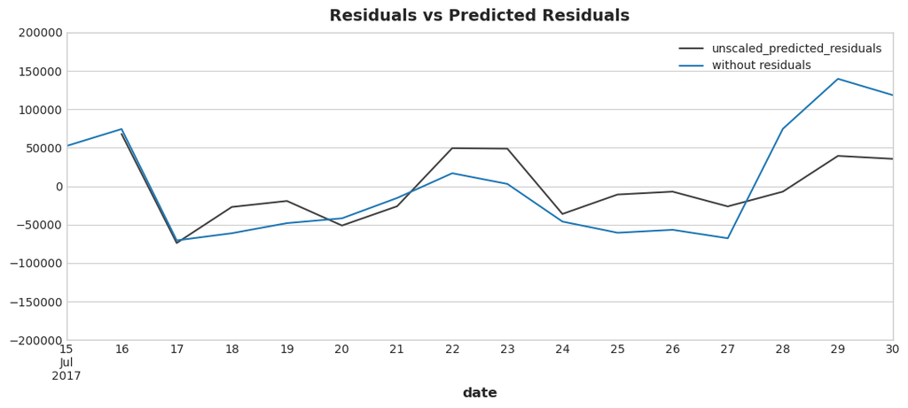

```python
fig, ax = plt.subplots()
(final_residuals_plot[final_residuals_plot.index > '2017-07-15']['unscaled_predicted_residuals']).plot(color='0.25', title="Residuals vs Predicted Residuals", ax=ax) # plots predicted residual values
final_residuals_plot['resid'].plot(ax=ax, label="without residuals") # plots actual residual values
plt.setp(ax, xlim=(['2017-07-15', '2017-07-30']),ylim=(-200000,200000))# sets date range to show on plot
plt.legend()
plt.show
```

```python
# calculates RMSE for residuals vs unscaled predicted residuals
np.sqrt(mean_squared_error(final_residuals_plot['resid'], final_residuals_plot['unscaled_predicted_residuals']))
```

```
124310.42146501748
```

We can make the same predictions using real lag values rather than our predicted values and see when we start to diverge

```python
actual_lags = all_data[all_data['date'] >= '2016-05-01'] # creates dataframe of all data after 5/1/2016
```

```python
actual_lags['scaled_residuals'] = stand_scaler.transform(actual_lags['resid'].values.reshape(-1,1)) # standardizes residual data
```

```python
actual_lags.head()
```

|  | id | date | store_nbr | family | onpromotion | national_holi | local_holi | regional_holi | new_year | payday | earthquake | dow | month | dcoilwtico | percip | max_temp | resid | scaled_residuals |
| --- | --- | --- | --- | --- | --- | --- | --- | --- | --- | --- | --- | --- | --- | --- | --- | --- | --- | --- |
| 2161566 | 2161566 | 2016-05-01 | 1 | AUTOMOTIVE | 0 | 1 | 0 | 0 | 0 | 0 | 1.0 | 6 | 5 | 0.0 | 156.27 | 27.84 | 0.589679 | 0.002415 |
| 2161567 | 2161567 | 2016-05-01 | 1 | BABY CARE | 0 | 1 | 0 | 0 | 0 | 0 | 1.0 | 6 | 5 | 0.0 | 156.27 | 27.84 | 0.000000 | 0.000429 |
| 2161568 | 2161568 | 2016-05-01 | 1 | BEAUTY | 0 | 1 | 0 | 0 | 0 | 0 | 1.0 | 6 | 5 | 0.0 | 156.27 | 27.84 | -1.557291 | -0.004817 |
| 2161569 | 2161569 | 2016-05-01 | 1 | BEVERAGES | 17 | 1 | 0 | 0 | 0 | 0 | 1.0 | 6 | 5 | 0.0 | 156.27 | 27.84 | -496.768819 | -1.672863 |
| 2161570 | 2161570 | 2016-05-01 | 1 | BOOKS | 0 | 1 | 0 | 0 | 0 | 0 | 1.0 | 6 | 5 | 0.0 | 156.27 | 27.84 | 0.005887 | 0.000449 |

```python
lag_data = actual_lags[:] # creates copy of lag data
df_lags = pd.DataFrame(columns = ['y_lag_1','y_lag_2','y_lag_3','y_lag_4','y_lag_5','y_lag_6','y_lag_7','y_lag_8','y_lag_9','y_lag_10','y_lag_11','y_lag_12'])# creates empty dataframe to store lag data

for n in list(range(1,55)): # iterates through store numbers
    for idx2, item2 in enumerate(cats): # iterates through family values
        frame = lag_data.query('store_nbr == '+str(n)+' and family == '+'"'+item2+'"') # creates dataframe of data from selected store / family

        frame = frame.set_index('id') # set id column as the dataframe index

        arry = frame['scaled_residuals'] # creates Series of scaled residual values

        lags = make_lags(arry, lags=12) # creates 12 lag variables from scaled residuals

        df_lags = pd.concat([df_lags,lags]) # appends store / family lag data to lag dataframe

lag_data = lag_data.merge(df_lags, how='left', left_index=True,  right_index=True) # adds lag data to features dataframe
```

```python
lag_data[['onpromotion','dow','month','dcoilwtico','percip','max_temp']] = max_scaler.transform(lag_data[['onpromotion','dow','month','dcoilwtico','percip','max_temp']]) # scales appropriate columns using min/max scaler

lag_data = pd.get_dummies(lag_data, columns = ['store_nbr','dow','month','family',], dtype='float32') # creates dummy variables (0 or 1) for appropriate columns

lag_data = lag_data.loc[2945646:] # creates dataframe of lag data after 7/15/2017

lag_data = lag_data.drop('id', axis=1) # drops id column from dataframe

lag_data = lag_data.drop(['scaled_residuals','resid'], axis=1) # drops residual and scaled residual columns from dataframe

col_list = X_test.drop('scaled_residuals', axis=1).columns # creates list of column names in correct order for prediction

lag_data = lag_data[col_list] # rearanges dataframe into correct order for prediction

predictions = predictionator_2(lag_data.to_numpy()[:,:]) # predicts values
```

```python
lag_data['predictions'] = predictions # adds predictions to dataframe
```

```python
lag_data['predictions'] = lag_data['predictions'].astype('float32') # changes prediction type from string to float
```

```python
lag_data['unscaled_predictions'] = stand_scaler.inverse_transform(lag_data['predictions'].values.reshape(-1,1)) # unscales predicted values
```

```python
lag_data = lag_data[['predictions','unscaled_predictions']] # creates dataframe of just predictions and unscaled predictions
```

```python
tail_plot = tail_plot.merge(lag_data, how='left', left_on='id', right_index=True) # adds predicted values to tail_plot
```

```python
lags_plot = tail_plot.groupby('date').sum() # groups dataframe by date, calculates sum
```

```python
lags_plot.head()
```

| date | id | resid | scaled_residuals | predicted_residuals | unscaled_predicted_residuals | scaled_actual_residuals | predictions | unscaled_predictions |
| --- | --- | --- | --- | --- | --- | --- | --- | --- |
| 2016-05-02 | 3856673007 | 94063.248635 | 317.602203 | 0.0 | 0.0 | 317.548 | 0.0 | 0.0 |
| 2016-05-03 | 3859848531 | 43542.471881 | 147.430435 | 0.0 | 0.0 | 147.393 | 0.0 | 0.0 |
| 2016-05-04 | 3863024055 | 32849.083382 | 111.411346 | 0.0 | 0.0 | 111.371 | 0.0 | 0.0 |
| 2016-05-05 | 3866199579 | -11192.869466 | -36.937454 | 0.0 | 0.0 | -36.980 | 0.0 | 0.0 |
| 2016-05-06 | 3869375103 | 46076.644683 | 155.966415 | 0.0 | 0.0 | 155.932 | 0.0 | 0.0 |

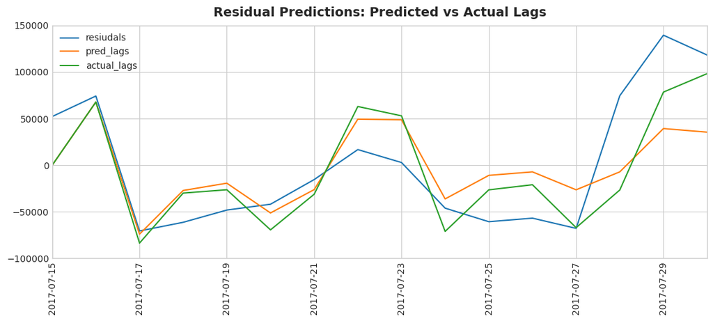

```python
import datetime as datetime

ax = plt.plot(lags_plot['resid'], label = 'resiudals') # plots residual data
ax = plt.plot(lags_plot['unscaled_predicted_residuals'], label ='pred_lags') # plots predictions using predicted lags
ax = plt.plot(lags_plot['unscaled_predictions'], label = 'actual_lags') # plots predictions using actual lags

plt.xlim([datetime.date(2017, 7,15), datetime.date(2017, 7, 30)]) # sets date range for plot
plt.ylim(-100000,150000) # sets y value range for plot
plt.xticks(rotation=90) # rotates x lables for better readability
plt.legend() # creates legend for plot
plt.title('Residual Predictions: Predicted vs Actual Lags') # creates title for plot
```

```python
# calculates RMSE for residuals vs predictions using predicted lags
np.sqrt(mean_squared_error(lags_plot['resid'],lags_plot['unscaled_predicted_residuals']))
```

```
124310.42146501748
```

```python
# calculates RMSE for residuals vs predictions using actual lags
np.sqrt(mean_squared_error(lags_plot['resid'],lags_plot['unscaled_predictions']))
```

```
124213.0669124193
```

Because our seasonal and trend predictions also include lag variables, we can either predict and append day by day like we did with our residuals or create a multi-step prediction with linear regression to predict X amount of days past our timeseries. For this project we will use multi-step.

```python
# creates function to predict multiple future values
def make_multistep_target(ts, steps):
    return pd.concat(
        {f'y_step_{i + 1}': ts.shift(-i)
         for i in range(steps)},
        axis=1)
```

```python
new2 = new[:] # makes a copy of our new dataframe
```

```python
new2['date'] = new.index.get_level_values(0) # creates date column from 'date' index
```

```python
new2 = new2[new2['date'] <= '2017-07-15'] # removes dates from dataframe that we will be predicting
```

```python
dates_pred = pd.DataFrame( columns = ['y_step_1', 'y_step_2', 'y_step_3', 'y_step_4', 'y_step_5', 'y_step_6',
       'y_step_7', 'y_step_8', 'y_step_9', 'y_step_10', 'y_step_11',
       'y_step_12', 'y_step_13', 'y_step_14', 'y_step_15','y_step_16','store_nbr','family']).fillna(0) # creates empty dataframe to store predicted values

for n in list(range(1,55)): # iterates through store numbers
    for i in cats: # iterates through family valies
        frame = new2.query('store_nbr == '+str(n)+' and family == '+'"'+i+'"') # create dataframe of selected store number and family category

        if np.sum(frame['sales'].values) == 0: # skips dataframes with no sales
            continue

        arry = frame['sales'].droplevel([1,2]) # creates Series of sales data
        '''
        for j in list(arry.index):
            if arry[j] < 0.01:
                arry = arry.drop(j)
            else:
                break
        '''


        fourier = CalendarFourier(freq="A", order=12) # creates calendar fourier values

        # defines dataframe consisting of constant and trend values of timeseries, with date as the index
        dp = DeterministicProcess(
        index=frame.index.get_level_values(0),
        constant=True,
        order=2,
        seasonal=True,
        additional_terms=[fourier],
        drop=True,
        )

        X = dp.in_sample() # creates deterministic dataframe for dates in index


        X2 = make_lags(arry, lags=9) # creates lag features for sales values
        X2 = X2.fillna(0.0) # fills null values with 0.0

        X3 = pd.merge(X,X2, left_on = X.index, right_on = X2.index) # combine dp and lag dataframes
        X3 = X3.set_index('key_0') # sets id as index

        y = arry[:] # creates copy of sales values by date (y)

        y = make_multistep_target(y, steps=16).dropna() # creates multistep target for sales values
        y, X5 = y.align(X3, join='inner', axis=0) # realigns X,y for model fitting


        # Fit and predict
        model = LinearRegression()
        model.fit(X5, y) # fits model to data

        y_pred = pd.DataFrame(model.predict(X3), index=frame.index.get_level_values(0), columns = y.columns) # creates dataframe of predicted multistep values
        y_pred['store_nbr'] = n # adds store number to prediction dataframe
        y_pred['family'] = i # adds family name to prediction dataframe
        dates_pred.loc[len(dates_pred)] = y_pred.iloc[-1].values # appends relevant predicted values to dates_pred dataframe
```

```python
dates_pred.head()
```

|  | y_step_1 | y_step_2 | y_step_3 | y_step_4 | y_step_5 | y_step_6 | y_step_7 | y_step_8 | y_step_9 | y_step_10 | y_step_11 | y_step_12 | y_step_13 | y_step_14 | y_step_15 | y_step_16 | store_nbr | family |
| --- | --- | --- | --- | --- | --- | --- | --- | --- | --- | --- | --- | --- | --- | --- | --- | --- | --- | --- |
| 0 | 4.65204 | 4.526765 | 4.095606 | 4.509798 | 4.342944 | 4.606913 | 4.7422 | 5.10039 | 4.555129 | 4.047862 | 4.538823 | 4.822184 | 5.193091 | 5.059455 | 5.081137 | 4.712572 | 1 | AUTOMOTIVE |
| 1 | 3.818111 | 3.477157 | 3.603333 | 3.76579 | 4.013879 | 3.888408 | 3.62447 | 4.074989 | 3.647402 | 3.951579 | 4.081086 | 4.089483 | 4.030901 | 3.967429 | 4.403751 | 3.819557 | 1 | BEAUTY |
| 2 | 2499.985649 | 1702.311168 | 2461.542833 | 2352.505219 | 2373.786196 | 2185.186087 | 2569.149421 | 2500.55777 | 1668.600652 | 2354.243434 | 2275.547971 | 2303.673852 | 2130.42248 | 2460.219321 | 2382.63221 | 1602.136383 | 1 | BEVERAGES |
| 3 | 0.830415 | 0.53174 | 0.598905 | 0.852175 | 0.634488 | 0.378044 | 0.407456 | 0.64336 | 0.657039 | 0.497003 | 0.698147 | 0.873018 | 0.458507 | 0.608598 | 0.539091 | 0.563271 | 1 | BOOKS |
| 4 | 423.944751 | 248.36488 | 438.818359 | 343.88254 | 437.266711 | 365.090766 | 377.655132 | 438.706512 | 247.643782 | 433.42035 | 333.986608 | 419.179244 | 357.306046 | 363.491655 | 424.001394 | 237.664116 | 1 | BREAD/BAKERY |

```python
# attaches dates to predicted columns
dates_pred.columns = ['2017-07-15','2017-07-16',
 '2017-07-17', '2017-07-18', '2017-07-19', '2017-07-20', '2017-07-21',
 '2017-07-22', '2017-07-23', '2017-07-24', '2017-07-25', '2017-07-26',
 '2017-07-27', '2017-07-28', '2017-07-29', '2017-07-30','store_nbr','family']
```

```python
part = pd.DataFrame(dates_pred.set_index(['store_nbr','family']).stack()) # rearranges dataframe
```

```python
part.reset_index(inplace=True) # resets dataframe index
```

```python
part.columns = ['store_nbr','family','date','pred_sales_steps'] # renames columns in dataframe
```

```python
part['date'] = part['date'].astype(str) # converts dataframe date to string for easier merging
```

```python
df_sales = df[['store_nbr','family','date','sales']] # selects relevant columns from original dataframe
df_sales['date'] = df_sales['date'].astype(str) # converts dataframe date to string for easier merging
```

```python
# merges dataframes to add sales column to 'part'
part = part.merge(df_sales, how='left', left_on = ['store_nbr','family','date'], right_on=['store_nbr','family','date'])
```

```python
part_plot = part.groupby('date').sum() # groups dataframe by date
```

```python
part_plot.index = pd.to_datetime(part_plot.index) # converts index to datetime
```

```python
part_plot.head()
```

| date | store_nbr | family | pred_sales_steps | sales |
| --- | --- | --- | --- | --- |
| 2017-07-15 | 47370 | AUTOMOTIVEBEAUTYBEVERAGESBOOKSBREAD/BAKERYCELE... | 908298.810791 | 9.690771e+05 |
| 2017-07-16 | 47370 | AUTOMOTIVEBEAUTYBEVERAGESBOOKSBREAD/BAKERYCELE... | 981172.26219 | 1.100804e+06 |
| 2017-07-17 | 47370 | AUTOMOTIVEBEAUTYBEVERAGESBOOKSBREAD/BAKERYCELE... | 822251.237883 | 8.183255e+05 |
| 2017-07-18 | 47370 | AUTOMOTIVEBEAUTYBEVERAGESBOOKSBREAD/BAKERYCELE... | 766475.042633 | 7.301337e+05 |
| 2017-07-19 | 47370 | AUTOMOTIVEBEAUTYBEVERAGESBOOKSBREAD/BAKERYCELE... | 781955.406354 | 7.679788e+05 |

```python
 # attaches new predictions and sales data to residual prediction dataframe
final_plot = pd.merge(final_residuals_plot, part_plot, how='left', left_on = 'date', right_on='date')
```

```python
final_plot = final_plot[final_plot.index > '2017-07-15'] # selects only relevant dates from dataframe
```

```python
final_plot.head()
```

| date | id | resid | scaled_residuals | predicted_residuals | unscaled_predicted_residuals | scaled_actual_residuals | store_nbr | family | pred_sales_steps | sales |
| --- | --- | --- | --- | --- | --- | --- | --- | --- | --- | --- |
| 2017-07-16 | 5250728043 | 74265.899920 | 0.0 | 229.267883 | 67838.703125 | 250.889 | 47370.0 | AUTOMOTIVEBEAUTYBEVERAGESBOOKSBREAD/BAKERYCELE... | 981172.26219 | 1.100804e+06 |
| 2017-07-17 | 5253903567 | -70582.523936 | 0.0 | -248.440567 | -73984.250000 | -237.002 | 47370.0 | AUTOMOTIVEBEAUTYBEVERAGESBOOKSBREAD/BAKERYCELE... | 822251.237883 | 8.183255e+05 |
| 2017-07-18 | 5257079091 | -61283.698358 | 0.0 | -90.560127 | -27112.287109 | -205.702 | 47370.0 | AUTOMOTIVEBEAUTYBEVERAGESBOOKSBREAD/BAKERYCELE... | 766475.042633 | 7.301337e+05 |
| 2017-07-19 | 5260254615 | -48138.182571 | 0.0 | -64.260994 | -19304.583984 | -161.405 | 47370.0 | AUTOMOTIVEBEAUTYBEVERAGESBOOKSBREAD/BAKERYCELE... | 781955.406354 | 7.679788e+05 |
| 2017-07-20 | 5263430139 | -41872.133388 | 0.0 | -171.848663 | -51245.667969 | -140.320 | 47370.0 | AUTOMOTIVEBEAUTYBEVERAGESBOOKSBREAD/BAKERYCELE... | 684970.775768 | 6.882881e+05 |

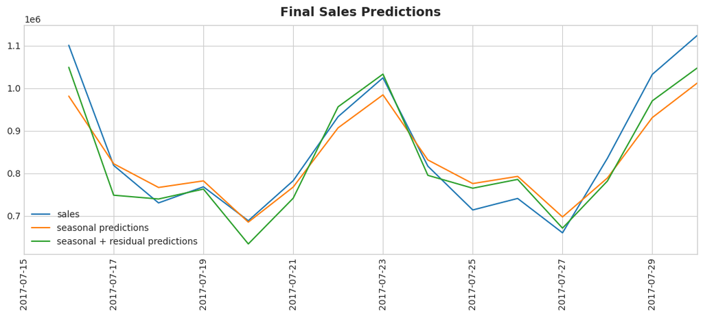

```python
import datetime as datetime
final_plot.index = pd.to_datetime(final_plot.index) # converts date to datetime for easier plotting

ax = plt.plot(final_plot['sales'], label = 'sales') # plots sales data
ax = plt.plot(final_plot['pred_sales_steps'], label = 'seasonal predictions') # plots seasonal predictions
ax = plt.plot((final_plot['pred_sales_steps'] + final_plot['unscaled_predicted_residuals']), label ='seasonal + residual predictions') # plots seasonal and residual predictions

plt.xlim([datetime.date(2017, 7,15), datetime.date(2017, 7, 30)])
plt.xticks(rotation=90)
plt.legend()
plt.title('Final Sales Predictions')
```

```python
# calculates RMSE for sales vs predicted sales
np.sqrt(mean_squared_error(final_plot['sales'],final_plot['pred_sales_steps']))
```

```
58596.11364191352
```

```python
# calculates RMSE for sales vs combined predicted sales and predicted residuals
np.sqrt(mean_squared_error(final_plot['sales'],(final_plot['pred_sales_steps']+final_plot['unscaled_predicted_residuals'])))
```

```
45283.96104247927
```

```python
# deletes endpoint hosting our model
predictor.delete_endpoint()
```

```
INFO:sagemaker:Deleting endpoint configuration with name: sagemaker-xgboost-2023-08-29-21-24-31-414
INFO:sagemaker:Deleting endpoint with name: sagemaker-xgboost-2023-08-29-21-24-31-414
```